# HW1 SP500_EDA

Elijah Hall

May 24, 2018

## HW#1 S&P500 EDA

In this assignment, you will conduct an exhaustive Exploratory Data Analysis (EDA) on the provided dataset. You will create new features and structure your EDA for different leads with sub-sections. Write a short summary of the features that you built and insight that they afforded at the end of each sub-section. Please submit in the HTML format.

### Merge all the files into one master

Combine all the data to make it easier to create features and apply them accross all stocks.

```r
#install.packages("tidyverse")
library(tidyverse)
#install.packages("data.table")
library(data.table)
#install.packages("TTR")
library(TTR)
library(zoo)
#install.packages("cumstats")
library(cumstats)
library(knitr)
library(rmarkdown)
```

```r
#read in data
stock_names <- read.table('SP500 Stocks.txt', sep=",", header=T)

# option two to merge all data files
data_path <- "C:/Users/usmc_/Documents/APAN 5420 Anomaly Detection/Anomaly Detection R/Stocks"   # path to the data
files <- dir(data_path, pattern = "*.txt") # get file names
# there are some empty files so I removed them

length(files)
# 7163 unique stocks from combination of exhanges
# create a data frame holding the file names, read files into a new data column
all <- data_frame(filename = files) %>%
  mutate(file_contents = map(filename,
            ~ read.table(file.path(data_path, .), sep=",", header=TRUE)))

all <- unnest(all)

all$filename <- toupper(str_split_fixed(all$filename, fixed("."), n = 2)[,1])

names(all)[1]<- "StockID"

all$Date<- as.Date(all$Date)

#fwrite(all,"all.csv")
# use fwrite instead of write.csv pr write_csv since it is much faster
# and use fread to bring back in file as an alternative to read.csv or read_csv
```

## Explore data

Now that the data is in one large file I want to look for obvious outliers.

```r
all<- fread("all.csv")

all$Date<- as.Date(all$Date)
```

“all.csv” is the file containing the data. It is 14.9 million rows. 16 columns, 2.6 GB in size.

```r
glimpse(all)
```

```
## Observations: 14,887,665
## Variables: 16
## $ StockID <chr> "A", "A", "A", "A", "A", "A", "A", "A", "A", "A", "A",...
## $ Date    <date> 1999-11-18, 1999-11-19, 1999-11-22, 1999-11-23, 1999-...
## $ Open    <dbl> 30.713, 28.986, 27.886, 28.688, 27.083, 27.594, 27.676...
## $ High    <dbl> 33.754, 29.027, 29.702, 29.446, 28.309, 28.012, 28.650...
## $ Low     <dbl> 27.002, 26.872, 27.044, 27.002, 27.002, 27.509, 27.380...
## $ Close   <dbl> 29.702, 27.257, 29.702, 27.002, 27.717, 27.807, 28.432...
## $ Volume  <dbl> 66277506, 16142920, 6970266, 6332082, 5132147, 1832635...
## $ returns <dbl> -0.033471634, -0.061502586, 0.063089613, -0.060567980,...
## $ CumRet  <dbl> -0.033471634, -0.094974220, -0.031884607, -0.092452587...
## $ rMean   <dbl> NA, NA, NA, NA, NA, NA, NA, NA, NA, NA, NA, NA, NA, NA...
## $ rVar    <dbl> 0.000000000, 0.000000000, 0.000000000, 0.000000000, 0....
## $ SR      <dbl> NA, NA, NA, NA, NA, NA, NA, NA, NA, NA, NA, NA, NA, NA...
## $ meanVar <dbl> NA, NA, NA, NA, NA, NA, NA, NA, NA, NA, NA, NA, NA, NA...
## $ sdVar   <dbl> NA, NA, NA, NA, NA, NA, NA, NA, NA, NA, NA, NA, NA, NA...
## $ NormVar <dbl> NA, NA, NA, NA, NA, NA, NA, NA, NA, NA, NA, NA, NA, NA...
## $ OOB     <int> NA, NA, NA, NA, NA, NA, NA, NA, NA, NA, NA, NA, NA, NA...
```

```r
head(all)
```

```
##    StockID       Date   Open   High    Low  Close   Volume     returns
## 1:       A 1999-11-18 30.713 33.754 27.002 29.702 66277506 -0.03347163
## 2:       A 1999-11-19 28.986 29.027 26.872 27.257 16142920 -0.06150259
## 3:       A 1999-11-22 27.886 29.702 27.044 29.702  6970266  0.06308961
## 4:       A 1999-11-23 28.688 29.446 27.002 27.002  6332082 -0.06056798
## 5:       A 1999-11-24 27.083 28.309 27.002 27.717  5132147  0.02313972
## 6:       A 1999-11-26 27.594 28.012 27.509 27.807  1832635  0.00768943
##         CumRet rMean rVar SR meanVar sdVar NormVar OOB
## 1: -0.03347163    NA    0 NA      NA    NA      NA  NA
## 2: -0.09497422    NA    0 NA      NA    NA      NA  NA
## 3: -0.03188461    NA    0 NA      NA    NA      NA  NA
## 4: -0.09245259    NA    0 NA      NA    NA      NA  NA
## 5: -0.06931287    NA    0 NA      NA    NA      NA  NA
## 6: -0.06162344    NA    0 NA      NA    NA      NA  NA
```

```r
tail(all)
```

```
##    StockID       Date  Open    High     Low Close Volume     returns
## 1:    ZYNE 2017-11-03  9.83 10.5000  9.8300 10.33 531495  0.04961335
## 2:    ZYNE 2017-11-06 10.42 11.5400 10.4200 11.19 977948  0.07129349
## 3:    ZYNE 2017-11-07 11.30 11.4200 10.6700 10.83 451210 -0.04248266
## 4:    ZYNE 2017-11-08 10.70 11.0600 10.3500 10.90 336449  0.01851905
## 5:    ZYNE 2017-11-09 11.00 11.8563 10.9700 11.60 463067  0.05310983
## 6:    ZYNE 2017-11-10 11.68 13.1500 11.3043 12.46 885587  0.06464554
##       CumRet rMean rVar SR meanVar sdVar NormVar OOB
## 1: -2.454552    NA    0 NA      NA    NA      NA  NA
## 2: -2.383258    NA    0 NA      NA    NA      NA  NA
## 3: -2.425741    NA    0 NA      NA    NA      NA  NA
## 4: -2.407222    NA    0 NA      NA    NA      NA  NA
## 5: -2.354112    NA    0 NA      NA    NA      NA  NA
## 6: -2.289466    NA    0 NA      NA    NA      NA  NA
```

```r
summary(all)
```

```
##    StockID               Date                 Open
##  Length:14887665    Min.   :1962-01-02   Min.   :0.000e+00
##  Class :character   1st Qu.:2007-11-29   1st Qu.:8.000e+00
##  Mode  :character   Median :2012-02-17   Median :1.600e+01
##                     Mean   :2010-06-19   Mean   :3.038e+04
##                     3rd Qu.:2015-05-21   3rd Qu.:2.900e+01
##                     Max.   :2017-11-10   Max.   :1.424e+09
##
##       High                Low                Close
##  Min.   :0.000e+00   Min.   :0.000e+00   Min.   :0.000e+00
##  1st Qu.:8.000e+00   1st Qu.:8.000e+00   1st Qu.:8.000e+00
##  Median :1.600e+01   Median :1.500e+01   Median :1.600e+01
##  Mean   :3.121e+04   Mean   :2.936e+04   Mean   :3.024e+04
##  3rd Qu.:2.900e+01   3rd Qu.:2.800e+01   3rd Qu.:2.900e+01
##  Max.   :1.442e+09   Max.   :1.362e+09   Max.   :1.438e+09
##
##      Volume             returns              CumRet
##  Min.   :0.000e+00   Min.   :-5.116387   Min.   :-35.96247
##  1st Qu.:3.280e+04   1st Qu.:-0.009437   1st Qu.: -0.63272
##  Median :1.923e+05   Median : 0.000000   Median :  0.07393
##  Mean   :1.586e+06   Mean   :-0.000121   Mean   :      Inf
##  3rd Qu.:8.918e+05   3rd Qu.: 0.009201   3rd Qu.:  0.92759
##  Max.   :2.424e+09   Max.   : 7.760880   Max.   :      Inf
##                      NA's   :15
##      rMean             rVar                 SR            meanVar
##  Min.   :-0.34    Min.   :0.0000000   Min.   :-5.51    Min.   :0.00
##  1st Qu.: 0.00    1st Qu.:0.0001130   1st Qu.:-0.58    1st Qu.:0.00
##  Median : 0.00    Median :0.0002849   Median : 0.00    Median :0.00
##  Mean   :  Inf    Mean   :0.0009009   Mean   : 0.01    Mean   :0.00
##  3rd Qu.: 0.00    3rd Qu.:0.0007324   3rd Qu.: 0.60    3rd Qu.:0.00
##  Max.   :  Inf    Max.   :3.1455720   Max.   : 5.68    Max.   :3.13
##  NA's   :225200                       NA's   :230270   NA's   :203772
##      sdVar           NormVar            OOB
##  Min.   :0.00     Min.   : -Inf    Min.   :0.00
##  1st Qu.:0.00     1st Qu.:-0.53    1st Qu.:0.00
##  Median :0.00     Median : 0.00    Median :0.00
##  Mean   :0.00     Mean   :  NaN    Mean   :0.01
##  3rd Qu.:0.00     3rd Qu.: 0.54    3rd Qu.:0.00
##  Max.   :1.59     Max.   :  Inf    Max.   :1.00
##  NA's   :203772   NA's   :225059   NA's   :225059
```

OpenInt is all 0’s and is likely caused by the aggregation process used to create the data files. I will not need this.

```r
#Remove OpenInt
ncol(all)
all <- all[,-8]

#Find where Low is -1
index<-which(all$Low<0)
all[(index-5):(index+5),]

# Open,High,Low,Close,Volume values from Yahoo finance for HLG on 2017-08-10
hlg_replace<- c(10.18,  10.98,  10.13,  10.35,  32600)
all[index,3:7] <- hlg_replace

#inspect where open and close were over $100B
head(all[which(all$Close>1000000000),])
tail(all[which(all$Close>1000000000),])

#fwrite(all,"all.csv")
```

[output not shown]

I found that the Open, High, Low, Close and Volume were all reported differenly on Yahoo Finance. I replaced the values for HLG with these confirmed values. Values on the days on either side matched and needed no further investigating.

The high open and close were related to DRYS and were found to be accurate after confirming Yahoo Finance.

## Build Features

### Log Returns and CumReturns

When comparing stocks the most common metric used is returns. When analyzing returns and market behavior it is customary to use log returns with is log(1+r). My returns feature is therefore log returns.

```r
#declare log returns
all<-all%>%
  group_by(StockID)%>%
  mutate(returns=log(1+((Close - Open)/Open)))
```

```r
#EDA
#inspect all returns
all %>%
  select(returns) %>%
  summary()
```

```
##     returns
##  Min.   :-5.116387
##  1st Qu.:-0.009437
##  Median : 0.000000
##  Mean   :-0.000121
##  3rd Qu.: 0.009201
##  Max.   : 7.760880
##  NA's   :15
```

```r
#view obervations
all$returns[which(all$returns==Inf)]
```

```
## numeric(0)
```

```r
#replace Inf with NA
all$returns[which(all$returns==Inf)] <-NA

#re-inspect
all %>%
  select(returns) %>%
  summary()
```

```
##     returns
##  Min.   :-5.116387
##  1st Qu.:-0.009437
##  Median : 0.000000
##  Mean   :-0.000121
##  3rd Qu.: 0.009201
##  Max.   : 7.760880
##  NA's   :15
```

```r
#Look at all stocks where
head(all[which(all$returns < -2),])

#look at the returns that is > -6
all[which(all$returns <-6),]


# SMBK true values for open and high
SMBK_replace <- c(16.90,    16.90   )
all[12295463,3:4]<- SMBK_replace
# fix returns
all$returns[12295463]<-  log(1+((all$Close[12295463] - all$Open[12295463])/all$Open[12295463]))

#BOFIL true values from yahoo
BOFIL_replace<-c(25.5, 25.3)
all[1937958,3:4] <-BOFIL_replace
# fix returns
all$returns[1937958]<-  log(1+((all$Close[1937958] - all$Open[1937958])/all$Open[1937958]))

#Replace TGEN data
TGEN_replace<-c(4.53,   5.17    )
all[13140186,3:4] <-TGEN_replace
# fix returns
all$returns[13140186]<-  log(1+((all$Close[13140186] - all$Open[13140186])/all$Open[13140186]))

#Replace GCBC data
GCBC_replace<-c(17.81,  19.00       )
all[5631431,3:4] <-GCBC_replace
# fix returns
all$returns[5631431]<-  log(1+((all$Close[5631431] - all$Open[5631431])/all$Open[5631431]))

#Replace PHII data
PHII_replace<-c(18.900, 20.950)
all[10707835,3:4] <-PHII_replace
# fix returns
all$returns[10707835]<-  log(1+((all$Close[10707835] - all$Open[10707835])/all$Open[10707835]))
```

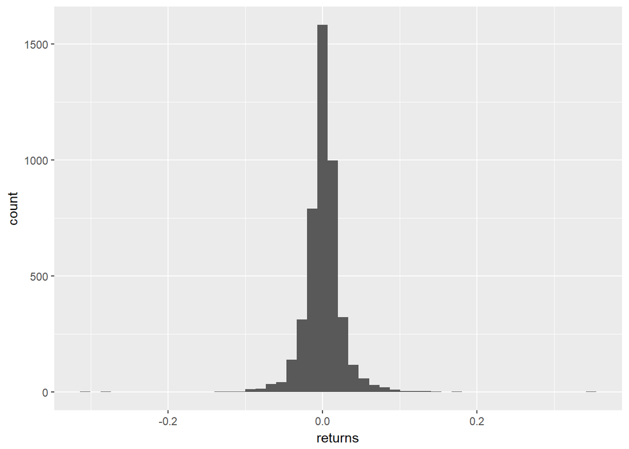

```r
#visualize distribution of first stock returns
ggplot(all[1:4500,], aes(x=returns)) + geom_histogram(bins=50)
```

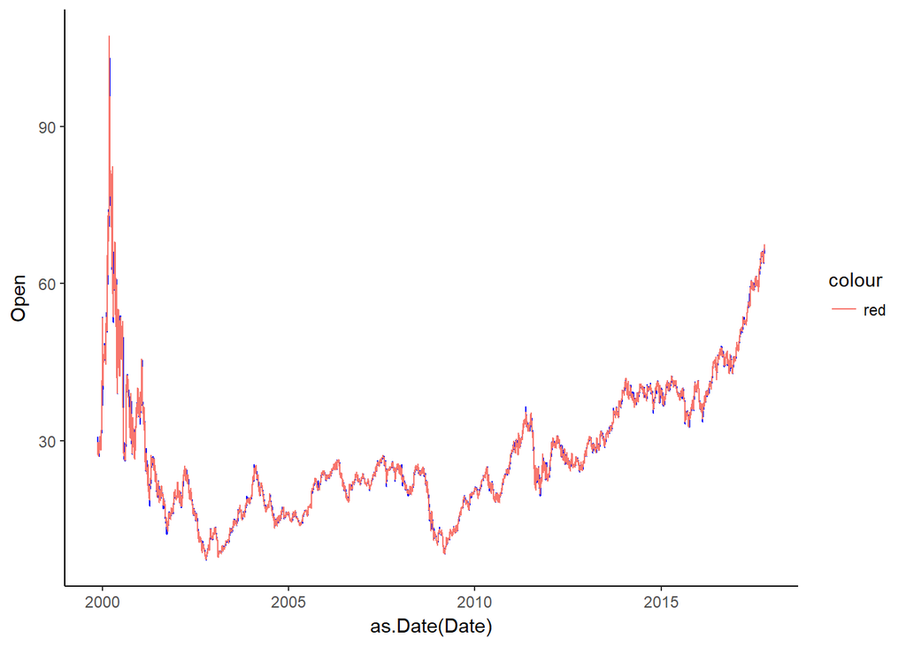

```r
#visual theme
mytheme <- theme_bw()+
  theme(panel.border = element_blank(),
        axis.line = element_line(color = 'black'),
        plot.background = element_blank(),
        panel.grid.major = element_blank(),
        panel.grid.minor = element_blank())


#visualize Open & Close
ggplot(all[1:4500,], aes(x=as.Date(Date), y=Open))+
  mytheme+
  geom_line(col="blue") +
  geom_line(aes(y=Close, col="red"))
```

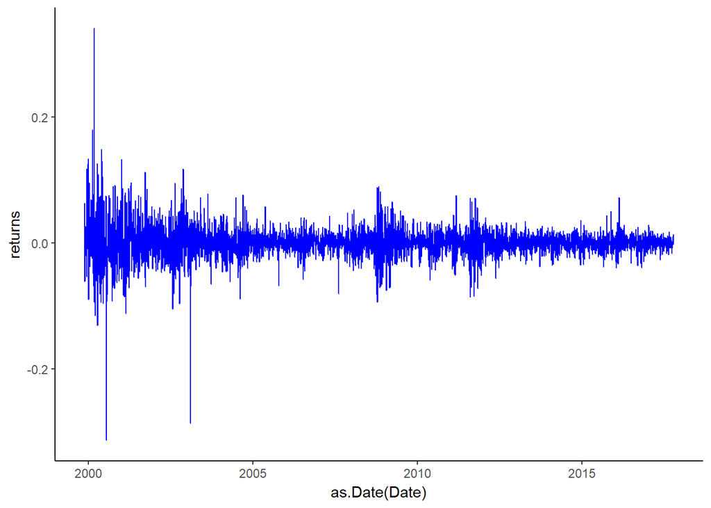

```r
#visualize returns
ggplot(all[1:4500,], aes(x=as.Date(Date), y=returns))+
  mytheme+
  geom_line(col="blue")
```

This is what I expect to see. The returns look consistent overall with a mean at 0 and normaly distributed. The spread and distributions look good. Nothing stands out.

The Opem and Close look to follow eachother without dramatic differences and appear to be normal. This would have to be looked at for more than one stock showever.

## Cumulative Returns

Cumulative returns is a way to evaluate overall returns for a specific investment. This can be used to evaluate a break even point, cash-out point, or other specific goals.

```r
#declare Cumulative returns
all<- all%>%
  group_by(StockID)%>%
  mutate(CumRet=cumsum(returns))
```

The Infinite values here were not fixed due to time. But will be fixed for part 2.

```r
#EDA
#inspect all returns
all %>%
  select(CumRet) %>%
  summary()
```

```
##      CumRet
##  Min.   :-35.96247
##  1st Qu.: -0.63272
##  Median :  0.07393
##  Mean   :      Inf
##  3rd Qu.:  0.92759
##  Max.   :      Inf
```

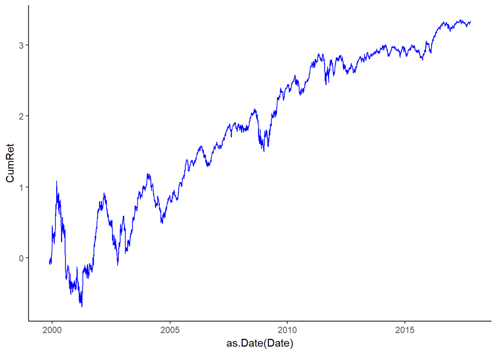

```r
#visualize distribution of first stock returns
ggplot(all[1:4500,], aes(x=as.Date(Date), y=CumRet))+
  mytheme +
  geom_line(col="blue")
```

## Rolling Mean

Another way to evaluate the value of a stock is its future value. This can be measured in many ways but the most common is its Expected returns. There are many ways to calculate this value. Some common way’s are a simple average, moving average, or weighted average. The wieghts can be set for various reasons one of which is to create a recency bias. I will use a simple rolling average.

```r
#rolling Mean (Simple Expected Returns last 30)
all<- all%>%
  group_by(StockID)%>%
  mutate(rMean = rollmean(returns, k = 30, na.pad = TRUE))
```

```r
#EDA
#inspect all returns
all %>%
  select(rMean) %>%
  summary()
```

```
##      rMean
##  Min.   :-0.34
##  1st Qu.: 0.00
##  Median : 0.00
##  Mean   :  Inf
##  3rd Qu.: 0.00
##  Max.   :  Inf
##  NA's   :225200
```

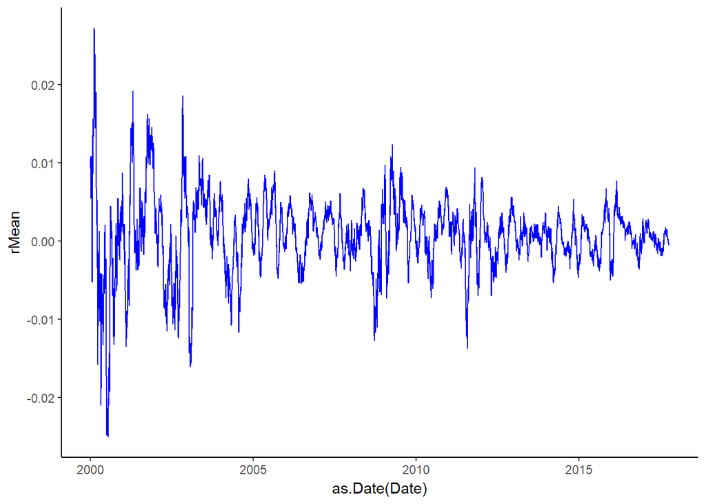

```r
#visualize distribution of first stock
ggplot(all[31:4500,], aes(x=as.Date(Date), y=rMean))+
  mytheme +
  geom_line(col="blue")
```

### Rolling Varriance

```r
#rolling monthly, 30 day, Variance
all<- all%>%
  group_by(StockID)%>%
  mutate(rVar = rollapply(returns, width = 30, FUN = var, na.pad = TRUE))
```

```r
# Start EDA
all %>%
  select(rVar) %>%
  summary()
```

```
##       rVar
##  Min.   :0.0000000
##  1st Qu.:0.0001130
##  Median :0.0002849
##  Mean   :0.0009009
##  3rd Qu.:0.0007324
##  Max.   :3.1455720
```

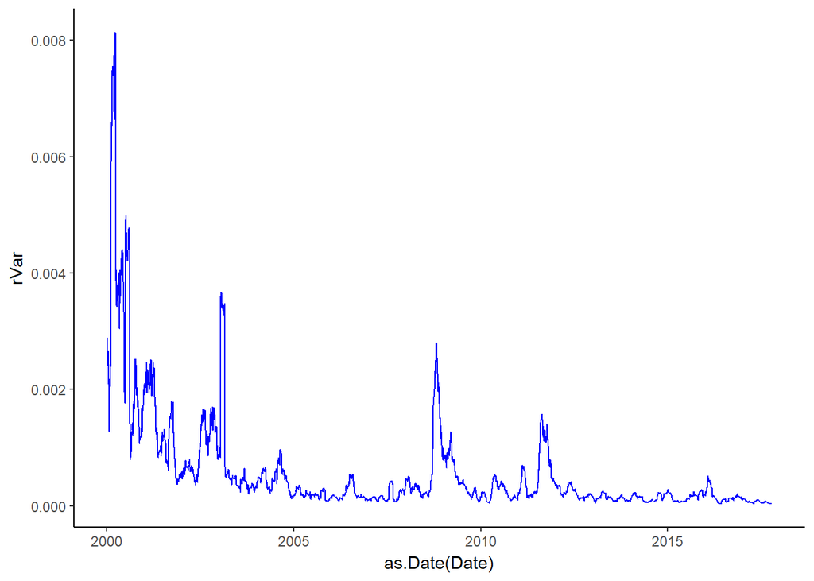

```r
#visualize distribution of first stock
ggplot(all[31:4500,], aes(x=as.Date(Date), y=rVar))+
  mytheme +
  geom_line(col="blue")
```

### Sharp Ratio

A performance measurement that describes the relationship between risk and return is the sharp ratio. This is used to measure returns over risk. The higher the value the better the score. The equation is (Returns - (risk free rate)) / sqrt(variance).

```r
#Sharp Ratio
all<- all%>%
  group_by(StockID)%>%
  mutate(SR = returns/sqrt(rVar))
```

```r
# Start EDA
all %>%
  select(SR) %>%
  summary()
```

```
##        SR
##  Min.   :-5.51
##  1st Qu.:-0.58
##  Median : 0.00
##  Mean   : 0.01
##  3rd Qu.: 0.60
##  Max.   : 5.68
##  NA's   :230270
```

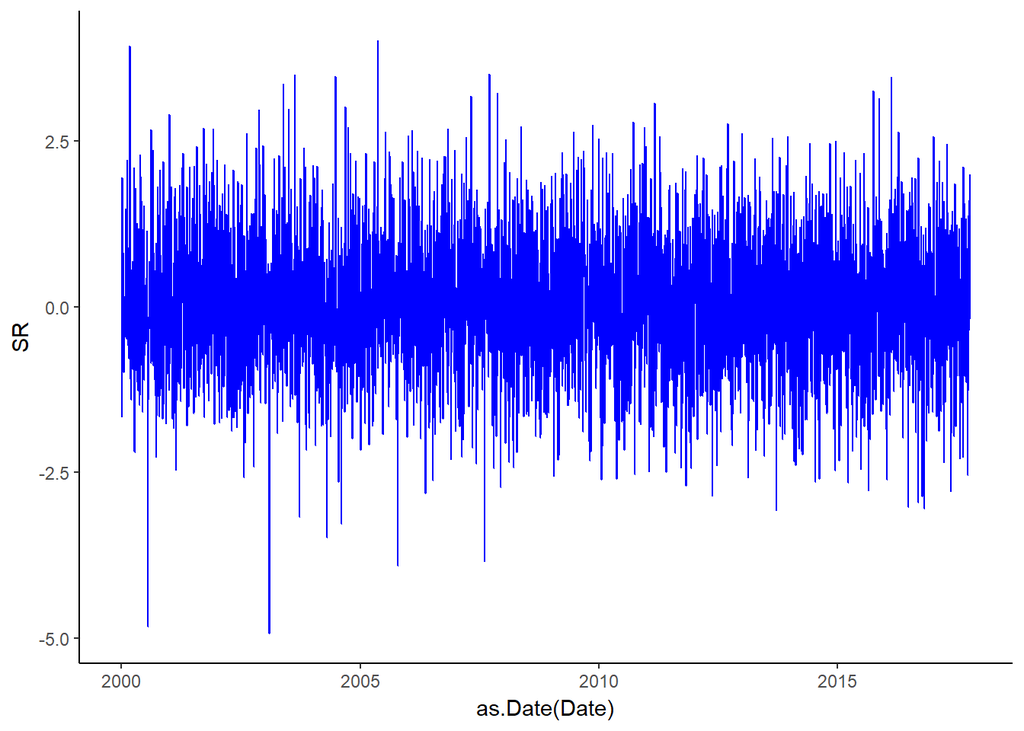

```r
#visualize distribution of first stock
ggplot(all[31:4500,], aes(x=as.Date(Date), y=SR))+
  mytheme +
  geom_line(col="blue")
```

### Normalized Variance

One measurement relative to risk that might be interesting is to find out how risky the short term period is relative to the long-term. Therefore normalizing the the risk will allow you to determine if the short term risk is beyond a certain distance, or evaluate the likelyhood of a the short term risk.

```r
#Replace NA's with 0's for now
na_index<-is.na(all$rVar)
all$rVar[na_index]<-0

#calculate mean, sd and normalized values for the rolling variance
all<- all%>%
  group_by(StockID)%>%
  mutate(meanVar = rollmean(rVar, k = 30, na.pad = TRUE), sdVar = rollapply(rVar, width = 30, FUN = sd, na.pad = TRUE), NormVar = (rVar - meanVar)/sdVar)

#Fill back in the NA's
all$rVar[na_index]<-NA
all$sdVar[na_index]<-NA
all$NormVar[na_index]<-NA
```

```r
# Start EDA
all %>%
  select(NormVar) %>%
  summary()
```

```
##     NormVar
##  Min.   : -Inf
##  1st Qu.:-0.53
##  Median : 0.00
##  Mean   :  NaN
##  3rd Qu.: 0.54
##  Max.   :  Inf
##  NA's   :225059
```

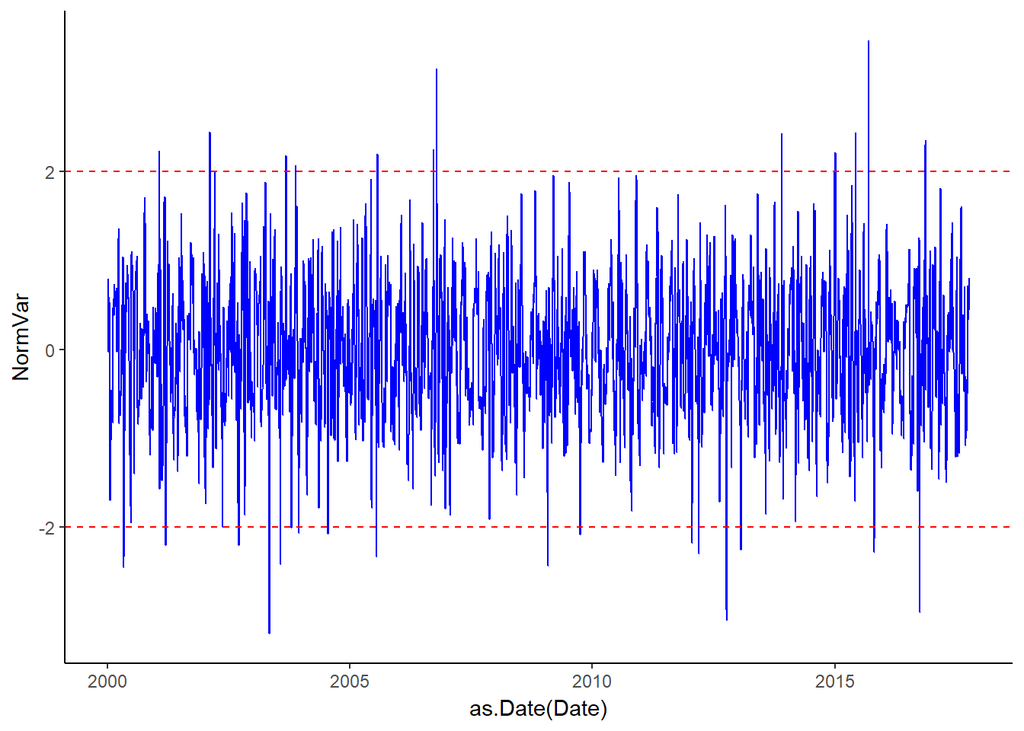

```r
#visualize distribution of first stock
ggplot(all[31:4500,], aes(x=as.Date(Date), y=NormVar))+
  mytheme +
  geom_line(col="blue") +
  geom_hline(yintercept = c(-2,2), col="red", lty=2)
```

The visual here makes it pretty easy to see that there are multiple events that aregoing beyond the normal boundaries. These events should be investigated further to identify if there are further issues with the data or if these are events of interest. A binary signal would be nice to be able to quickly identify the crossing of these boundary lines.

### Binary out-of-bounds > +- 1.96 SD’s

This indicator is just an easy way to identify those values that are beyond the 95% quantile for risk. This is a transformation of NormVar.

```r
#Create Binary variabel to determine if Variance is more than 1.96 sd's away

all<- all%>%
  group_by(StockID)%>%
  mutate(OOB =  as.numeric(NormVar>=1.96|NormVar<= (-1.96)))

#fwrite(all, "all.csv")

##saving RData files instead of csv
#save(all, file="all.rda")
#load("all.rda")
```

I want to know how many times the risk or variance of stocks goes outside of the expected bounds. I expect no more than 5% since that is the limit I set NormVar.

```r
#proportion of occurances out of bounds
mean(all$OOB,na.rm = T)
```

```
## [1] 0.00788782
```

```r
#less than 1%
```

I find it curious that less than 1% of all varianc measurments occure outside the boundaries. This could be due to the fact that we are using a rolling variance and not a more academic approach to calculating variance.

One last look at the data.

```r
glimpse(all)
```

```
## Observations: 14,887,665
## Variables: 16
## $ StockID <chr> "A", "A", "A", "A", "A", "A", "A", "A", "A", "A", "A",...
## $ Date    <date> 1999-11-18, 1999-11-19, 1999-11-22, 1999-11-23, 1999-...
## $ Open    <dbl> 30.713, 28.986, 27.886, 28.688, 27.083, 27.594, 27.676...
## $ High    <dbl> 33.754, 29.027, 29.702, 29.446, 28.309, 28.012, 28.650...
## $ Low     <dbl> 27.002, 26.872, 27.044, 27.002, 27.002, 27.509, 27.380...
## $ Close   <dbl> 29.702, 27.257, 29.702, 27.002, 27.717, 27.807, 28.432...
## $ Volume  <dbl> 66277506, 16142920, 6970266, 6332082, 5132147, 1832635...
## $ returns <dbl> -0.033471634, -0.061502586, 0.063089613, -0.060567980,...
## $ CumRet  <dbl> -0.033471634, -0.094974220, -0.031884607, -0.092452587...
## $ rMean   <dbl> NA, NA, NA, NA, NA, NA, NA, NA, NA, NA, NA, NA, NA, NA...
## $ rVar    <dbl> 0.000000000, 0.000000000, 0.000000000, 0.000000000, 0....
## $ SR      <dbl> NA, NA, NA, NA, NA, NA, NA, NA, NA, NA, NA, NA, NA, NA...
## $ meanVar <dbl> NA, NA, NA, NA, NA, NA, NA, NA, NA, NA, NA, NA, NA, NA...
## $ sdVar   <dbl> NA, NA, NA, NA, NA, NA, NA, NA, NA, NA, NA, NA, NA, NA...
## $ NormVar <dbl> NA, NA, NA, NA, NA, NA, NA, NA, NA, NA, NA, NA, NA, NA...
## $ OOB     <int> NA, NA, NA, NA, NA, NA, NA, NA, NA, NA, NA, NA, NA, NA...
```

```r
head(all[-30,],10)
```

```
##     StockID       Date   Open   High    Low  Close   Volume      returns
##  1:       A 1999-11-18 30.713 33.754 27.002 29.702 66277506 -0.033471634
##  2:       A 1999-11-19 28.986 29.027 26.872 27.257 16142920 -0.061502586
##  3:       A 1999-11-22 27.886 29.702 27.044 29.702  6970266  0.063089613
##  4:       A 1999-11-23 28.688 29.446 27.002 27.002  6332082 -0.060567980
##  5:       A 1999-11-24 27.083 28.309 27.002 27.717  5132147  0.023139719
##  6:       A 1999-11-26 27.594 28.012 27.509 27.807  1832635  0.007689430
##  7:       A 1999-11-29 27.676 28.650 27.380 28.432  4317826  0.026949660
##  8:       A 1999-11-30 28.350 28.986 27.634 28.480  4567146  0.004575056
##  9:       A 1999-12-01 28.480 29.324 28.273 28.986  3133746  0.017610868
## 10:       A 1999-12-02 29.532 30.375 29.155 29.786  3252997  0.008564063
##           CumRet rMean rVar SR meanVar sdVar NormVar OOB
##  1: -0.033471634    NA    0 NA      NA    NA      NA  NA
##  2: -0.094974220    NA    0 NA      NA    NA      NA  NA
##  3: -0.031884607    NA    0 NA      NA    NA      NA  NA
##  4: -0.092452587    NA    0 NA      NA    NA      NA  NA
##  5: -0.069312868    NA    0 NA      NA    NA      NA  NA
##  6: -0.061623438    NA    0 NA      NA    NA      NA  NA
##  7: -0.034673779    NA    0 NA      NA    NA      NA  NA
##  8: -0.030098722    NA    0 NA      NA    NA      NA  NA
##  9: -0.012487854    NA    0 NA      NA    NA      NA  NA
## 10: -0.003923791    NA    0 NA      NA    NA      NA  NA
```

```r
tail(all,10)
```

```
##     StockID       Date  Open    High     Low Close Volume      returns
##  1:    ZYNE 2017-10-30  9.80 10.2699  9.6300  9.76 256138 -0.004089985
##  2:    ZYNE 2017-10-31  9.74  9.9492  9.6300  9.80 233242  0.006141268
##  3:    ZYNE 2017-11-01  9.70  9.9300  9.4100  9.69 301604 -0.001031460
##  4:    ZYNE 2017-11-02  9.59 10.2000  9.5100  9.85 323496  0.026750566
##  5:    ZYNE 2017-11-03  9.83 10.5000  9.8300 10.33 531495  0.049613349
##  6:    ZYNE 2017-11-06 10.42 11.5400 10.4200 11.19 977948  0.071293486
##  7:    ZYNE 2017-11-07 11.30 11.4200 10.6700 10.83 451210 -0.042482665
##  8:    ZYNE 2017-11-08 10.70 11.0600 10.3500 10.90 336449  0.018519048
##  9:    ZYNE 2017-11-09 11.00 11.8563 10.9700 11.60 463067  0.053109825
## 10:    ZYNE 2017-11-10 11.68 13.1500 11.3043 12.46 885587  0.064645536
##        CumRet rMean rVar SR meanVar sdVar NormVar OOB
##  1: -2.536025    NA    0 NA      NA    NA      NA  NA
##  2: -2.529884    NA    0 NA      NA    NA      NA  NA
##  3: -2.530916    NA    0 NA      NA    NA      NA  NA
##  4: -2.504165    NA    0 NA      NA    NA      NA  NA
##  5: -2.454552    NA    0 NA      NA    NA      NA  NA
##  6: -2.383258    NA    0 NA      NA    NA      NA  NA
##  7: -2.425741    NA    0 NA      NA    NA      NA  NA
##  8: -2.407222    NA    0 NA      NA    NA      NA  NA
##  9: -2.354112    NA    0 NA      NA    NA      NA  NA
## 10: -2.289466    NA    0 NA      NA    NA      NA  NA
```

```r
names(all)
```

```
##  [1] "StockID" "Date"    "Open"    "High"    "Low"     "Close"   "Volume"
##  [8] "returns" "CumRet"  "rMean"   "rVar"    "SR"      "meanVar" "sdVar"
## [15] "NormVar" "OOB"
```

All the features relate to returns and the relationship between Open and Close. These features are therefore highly coorolated and migh not be very usefull together. Some additional features that would have been usefull would have been relationships with returns and volume. However due to time I did not create these features.